```python
print('Hello World')
```

```
Hello World
```

# Food Hub Presentation

Hello!

Prior to presenting this project, we need to import the required libraries.

```python
# imported libraries for data manipulation
import numpy as np
import pandas as pd

# imported libraries for data visualization
import matplotlib.pyplot as plt
import seaborn as sns

# Imported the DataFrame as DF
df = pd.read_csv('/content/foodhub_order.csv')
```

# Question 1: How many rows and columns are present in the data?

```python
df.shape
```

```
(1898, 9)
```

When imputting the code df.shape, it can conclude there are 1898 rows and 9 columns.

# Question 2: What are the datatypes of the different columns in the dataset?

```python
df.info()
```

```
<class 'pandas.core.frame.DataFrame'>
RangeIndex: 1898 entries, 0 to 1897
Data columns (total 9 columns):
 #   Column                 Non-Null Count  Dtype
---  ------                 --------------  -----
 0   order_id               1898 non-null   int64
 1   customer_id            1898 non-null   int64
 2   restaurant_name        1898 non-null   object
 3   cuisine_type           1898 non-null   object
 4   cost_of_the_order      1898 non-null   float64
 5   day_of_the_week        1898 non-null   object
 6   rating                 1898 non-null   object
 7   food_preparation_time  1898 non-null   int64
 8   delivery_time          1898 non-null   int64
dtypes: float64(1), int64(4), object(4)
memory usage: 133.6+ KB
```

The dataframe contains nine columns containing data types with five numerical types (integers and floats). The other four are object data types meaning these columns do not have numerical values.

# Question 3: Are there any missing values in the data?

```python
df.info()
```

```
<class 'pandas.core.frame.DataFrame'>
RangeIndex: 1898 entries, 0 to 1897
Data columns (total 9 columns):
 #   Column                 Non-Null Count  Dtype
---  ------                 --------------  -----
 0   order_id               1898 non-null   int64
 1   customer_id            1898 non-null   int64
 2   restaurant_name        1898 non-null   object
 3   cuisine_type           1898 non-null   object
 4   cost_of_the_order      1898 non-null   float64
 5   day_of_the_week        1898 non-null   object
 6   rating                 1898 non-null   object
 7   food_preparation_time  1898 non-null   int64
 8   delivery_time          1898 non-null   int64
dtypes: float64(1), int64(4), object(4)
memory usage: 133.6+ KB
```

```python
df.isnull().sum()
```

```
order_id                 0
customer_id              0
restaurant_name          0
cuisine_type             0
cost_of_the_order        0
day_of_the_week          0
rating                   0
food_preparation_time    0
delivery_time            0
dtype: int64
```

The first line of code will determine the data set does not contain any missing values due to each column says it is "non-null" meaning no missing values. In the second line of code the insull and sum functions retruns a DataFrame object where all the values are replaced with a Boolean value. In combination with the sum function it returns the number of missing values in the data set, meaning there are no missing values in the data set.

# Question 4: What is the statistical summary of the data for food preparation?

```python
df['food_preparation_time'].describe().T
```

```
count    1898.000000
mean       27.371970
std         4.632481
min        20.000000
25%        23.000000
50%        27.000000
75%        31.000000
max        35.000000
Name: food_preparation_time, dtype: float64
```

# Question 5: How many orders are not rated?

```python
df['rating'].value_counts()
```

```
Not given    736
5            588
4            386
3            188
Name: rating, dtype: int64
```

The code above confirms there are 736 orders that were not given a rating.

# Question 6: Exploring variables, observations, and distributions.

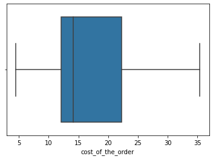

```python
sns.boxplot(data=df, x='cost_of_the_order');
```

When observing the boxplot regarding the cost of the order, no outlier are present, contains a good distribution among price.

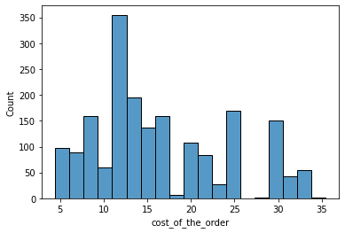

```python
sns.histplot(data=df, x='cost_of_the_order');
```

While the histoplot presents a different point of reference as compared to the boxplot, showing a greater frequency betwen the price range of 12-18 dollars.

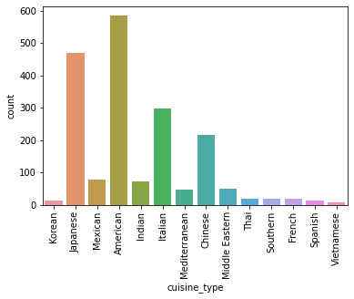

```python
sns.countplot(data=df, x='cuisine_type');
plt.xticks(rotation=90)
```

The countplot discovers the frequency and amount of cuisine type ordered.

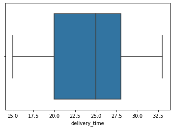

```python
sns.boxplot(data=df, x='delivery_time');
```

When placing the delivery time in a box plot, no outliers

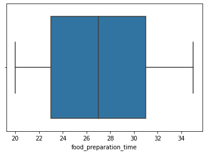

```python
sns.boxplot(data=df, x='food_preparation_time')
```

As well with food preparation, no outliers.

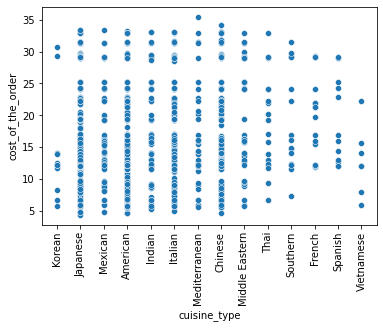

```python
sns.scatterplot(data=df, x='cuisine_type', y='cost_of_the_order');
plt.xticks(rotation=90);
```

There is not much correlation between cuisine type and cost of the order.

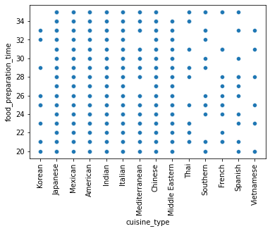

```python
sns.scatterplot(data=df, x='cuisine_type', y='food_preparation_time');
plt.xticks(rotation=90);
```

As well not mich correlation between cuisione type and food preparation time.

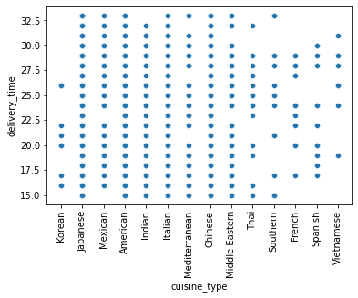

```python
sns.scatterplot(data=df, x='cuisine_type', y='delivery_time');
plt.xticks(rotation=90);
```

The same goes for delivery time and cuisine type.

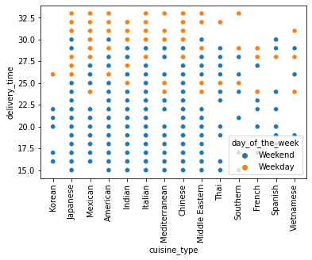

```python
sns.scatterplot(data=df, x='cuisine_type', y='delivery_time', hue='day_of_the_week');
plt.xticks(rotation=90);
```

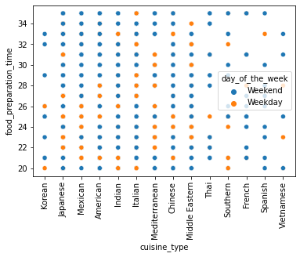

```python
sns.scatterplot(data=df, x='cuisine_type', y='food_preparation_time', hue='day_of_the_week');
plt.xticks(rotation=90);
```

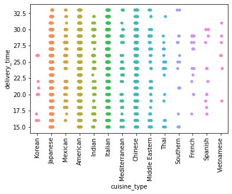

```python
sns.stripplot(data=df, x='cuisine_type', y='delivery_time');
plt.xticks(rotation=90);
```

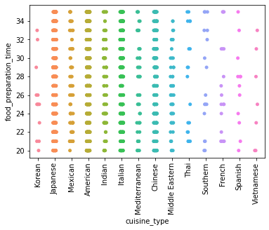

```python
sns.stripplot(data=df, x='cuisine_type', y='food_preparation_time');
plt.xticks(rotation=90);
```

The scatterplot as well determines the lack of correlation between the variables.

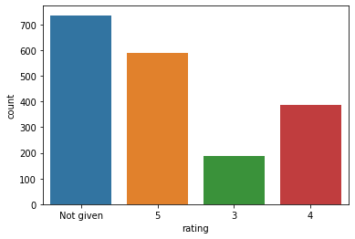

```python
sns.countplot(data=df, x='rating');
```

[output not shown]

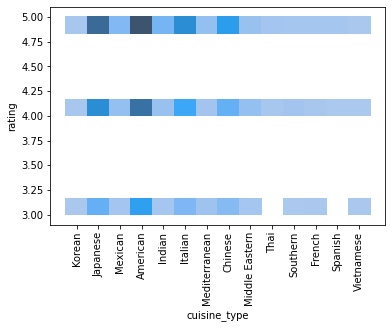

```python
sns.histplot(data=df, x='cuisine_type', y='rating')
plt.xticks(rotation=90)
```

There is a descending correlation between ratings and cuisine type.

# Question 7: Top 5 restraurants who received the most orders

[figure not shown]

```python
plt.figure(figsize=(100,20))
sns.countplot(data=df, x='restaurant_name');
plt.xticks(rotation=90)
plt.show()
```

The count plot function inputted all the restaurants, but the issue at hand is there is an abduance of variables, and so below the there is a code to shows the correct variables.

```python
df['restaurant_name'].value_counts().head()
```

```
Shake Shack                  219
The Meatball Shop            132
Blue Ribbon Sushi            119
Blue Ribbon Fried Chicken     96
Parm                          68
Name: restaurant_name, dtype: int64
```

# Question 8: Most popular cuisine on weekends.

```python
df[df['day_of_the_week']=='Weekend'].value_counts(['cuisine_type']).head(1)
```

```
cuisine_type
American        415
dtype: int64
```

American is the most popular cuisine on the weekends.

# Question 9: Percentage of orders that cost more than 20 dollars.

```python
x = df[df['cost_of_the_order']>20].value_counts().sum()
per = 100
y = df['cost_of_the_order'].value_counts().sum()
z = x/y
print(z)
```

```
0.2924130663856691
```

As observed from the code above, 29.24% of the orders are over 20 dollars.

# Question 10: Delivery time mean

```python
df['delivery_time'].mean()
```

```
24.161749209694417
```

The mean for devliery time is 24 minutes and 9.6 seconds.

# Question 11: The top 5 frequent customers who will recieve a discount voucher.

```python
df['customer_id'].value_counts().head()
```

```
52832     13
47440     10
83287      9
250494     8
259341     7
Name: customer_id, dtype: int64
```

The Data Frame determines the different customers have a specific ID. Created a groupby of the customer ID, configured the data count and created a head.

# Question 12: Multivariate analyis

```python
df.corr()
```

[output not shown]

[figure not shown]

```python
sns.heatmap(df.corr(), annot = True, cmap='YlGnBu');
```

A multivariate analysis is based in observation and analysis of more than one statistical outcome variable at a time. In design and analysis, the technique is used to perform trade studies across multiple dimensions while taking into account the effects of all variables on the responses of interest. As we can observe through the correlation chart and heatmap, most of the variables do not have much correlation amongst each other. The variables have either low or negative correlations amongst each other meaning they are not invertly directed with one another and so the data is random. This could be due to the abundance random outcome of variables in the data and so it is hard to configure a correlation. If we were to look at the heatmap, the data correlation is givin a vizualization. In a heat map, an individual square contains the correlations between two data variables, the darker the square the greater the correlation, the lighter the less. In the heat map, it can be observed there is a lack of correlation between the variables, and in some instances there are negative correlations. In conclusion, the multivariate analysis determines there is little to negative correlation between the data variables.

# Question 13: The company wants to provide a promotional offer in the advertisement of the restaurants. The condition to get the offer is that the restaurants must have a rating count of more than 50 and the average rating should be greater than 4.

```python
df[df['rating']>4].value_counts(['restaurant_name'])
```

[output not shown]

When we first input the code, there is an error. 'Ratings' is not an interger, but instead an object data type and we have to convert the category into a float data type.

Python is indicating there are values 'not given' but python computes this into an object and we have to convert the 'not given' value into a nan variable.

```python
df['rating']=df['rating'].replace(['Not given'], np.nan)
```

This function allows to replace the 'Not given' value to nan.

```python
df['rating'] = df['rating'].astype(float)
```

Following the function, command python to convery the data type from an object to float, hence creating the data set into an interger.

```python
df[df['rating']>4].value_counts(['restaurant_name']).head()
```

```
restaurant_name
Shake Shack                  60
The Meatball Shop            53
Blue Ribbon Sushi            32
Blue Ribbon Fried Chicken    32
RedFarm Broadway             18
dtype: int64
```

Once the data set was changed, we are able to conclude Shake Shack and The Meatball Shop will be offered promotional advertisment.

# Question 14: The company charges the restaurant 25% on the orders having cost greater than 20 dollar and 15% on the orders having cost greater than 5 dollars, while locating the net revenue.

```python
x = df[df['cost_of_the_order']>20].sum()
revenue = x['cost_of_the_order']
print("The net revenue is", round(revenue * .75, 2), "dollars")
```

```
The net revenue is 11066.18 dollars
```

```python
y = df[df['cost_of_the_order'].between(5,20)].sum()
lessRevenue = y['cost_of_the_order']
print("The net revenue is", round(lessRevenue * .85, 2), "dollars")
```

```
The net revenue is 14039.59 dollars
```

# Question 15: Finding the percentage of food delivered in 60 minutes.

```python
df['time'] = df['food_preparation_time'] + df['delivery_time']
x = df[df['time']>60].value_counts().sum()
y = df['time'].value_counts().sum()
print("The percentage of food prepared and delivered averaging more than 60 minutes is", round(x/y, 2),"percent")
```

[output not shown]

# Question 16: The company wants to analyze the delivery time of the orders on weekdays and weekends. How does the mean delivery time vary during weekdays and weekends

```python
df.loc[df['day_of_the_week'] == 'Weekend', 'delivery_time'].mean()
```

```
22.4700222057735
```

```python
df.loc[df['day_of_the_week'] == 'Weekday', 'delivery_time'].mean()
```

```
28.340036563071298
```

The average delviery time on weekdays is 28 minutes and 21 second, while on weekends its 22 minutes and 29 seconds.

# Question 17: Conclusion and Recommendations

```python
df.corr()
```

[output not shown]

[figure not shown]

```python
sns.heatmap(df.corr(), annot = True, cmap='YlGnBu');
```

Conclusion: The purpose of this study was to provide an analysis for a food delivery app, focusing in New York. The app Food Hub, allows customers to order food from local restaurants and have it delivered. This app is convienent for New York due to the hectic life of the city. It could be concluded there is a lack of data correlation between the variables, and so it would be difficult to find correlation. Though, it must said there are restaurants and cuisines that are more popular than others, in particular American restaurants. Now, it makes sense in New York, American is the most popular due to location and familairity, but there are other factors for other cuisines. The multivariate analysis confirms there is a lack of correlation between the two variables, ratings, food time cooked and delivered, does not determine the amount of business brought to the business, but there are recommendations.

Recommendations: The first recommendation is to observe the cuisine type with the least amount of business. Presented below those businesses do not have a consistent food prep and delivery time. There is a limited amount of restaurants that provide these specific cuisines, and in order to drive business the app must provide a promotion for these establishments in order to drive sales. The app should require a certain percentage of their sales in order to promote their restaurants. Every week or Food Hub should select Thai for example and tell customers they will eliminate their delivery charge if they order from Thai restaurants. Focus goes towards Thai, sales go up, there is a greater familirarity with the product. Increase the sales number, this will increase the consistency of the times, and consistency will create a larger customer base.

```
([0, 1, 2, 3, 4, 5, 6, 7, 8, 9, 10, 11, 12, 13],
 <a list of 14 Text major ticklabel objects>)
```

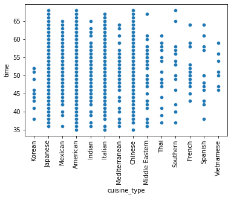

```python
sns.scatterplot(data=df, x='cuisine_type', y='time')
plt.xticks(rotation=90)
```

```python
df['cuisine_type'].value_counts()
```

```
American          584
Japanese          470
Italian           298
Chinese           215
Mexican            77
Indian             73
Middle Eastern     49
Mediterranean      46
Thai               19
French             18
Southern           17
Korean             13
Spanish            12
Vietnamese          7
Name: cuisine_type, dtype: int64
```

Another recommendation is to increase ratings, espeically for the cuisines with the least amount of orders. Below on the histoplot, the more popular cuisine type have a descending order of 5.0 ratings to 3.0. The less ordered cuisines have a constient flow of ratings. It has been proven American is the most popular cuisine, but they as well receive bad reviews. The reason the less ordered cuisines have is due to volume, and in order to increase ratings is to offer promotions to customers to increase sales in the less ordered cuisine types.

```
([0, 1, 2, 3, 4, 5, 6, 7, 8, 9, 10, 11, 12, 13],
 <a list of 14 Text major ticklabel objects>)
```

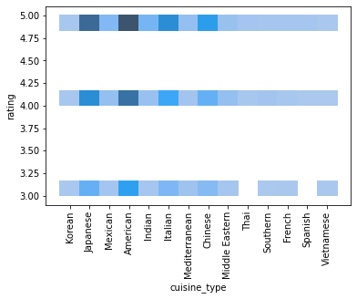

```python
sns.histplot(data=df, x='cuisine_type', y='rating')
plt.xticks(rotation=90)
```

My overall recommendation is to offer promotions to customers for less ordered cuisines. New York is an American city and American cuisine would be the most ordered food. New York is also an international city where multiple different nationals, ethnicities, and cultures reside. These natives might not know of Food Hub and their capability to order and eat food related to their homeland. This will not only drive food sales for less ordered cuisines, but the app could expand into international markets.